# R 프로그래밍: 엑셀화일과 자료 처리

이용희

2019년 3월

# R에서 MS 엑셀화일을 불러들이는 방법

## 예제: 엑셀 화일의 구성

MS 엑셀화일(Miscrosoft Excel file)은 자료를 저장하고 정리하는데 매우 유용한 프로그램이다. 이번에는 R에서 MS 엑셀화일을 불러들여서 데이카프레임 형식으로 저장하는 방법을 소개한다.

아래 그림과 같이 2014-2018년의 서울시 구별 인구정보가 `test.xlsx` 엑셀 화일에 저장되어 있다고 가정하자.

[figure not shown]

## 패키지의 설치와 이용 지정

### 패키지 `readxl`의 설치

R은 독자적으로도 여러 가지 다양한 기능을 수행할 수 있는 통계 프로그램이지만 다양한 기능을 제공하는 패키지(poackage)를 설치하면 더욱 편리한 기능을 이용할 수 있다.

MS 엑셀화일은 여러 가지 형식(xls, xlsx, csv, …)이 있기 때문에 엑셀화일을 수월하게 읽을 수 있는 패키지 `readxl`을 설치하여 이용하면 쉽게 엑셀화일의 자료를 데이터프레임으로 변환하여 사용할 수 있다.

패키지의 설치는 두 가지 방법이 있다.

1. **plot** 패널에서 `packages` 탭을 클릭하면 install 버튼이 있다. install 버튼을 클릭하면 대화창이 뜨고 설치하고자 하는 패키지의 이름을 입력하여 선택한다. 아래 있는 install 버튼을 클릭하면 패키지를 설치해 준다.

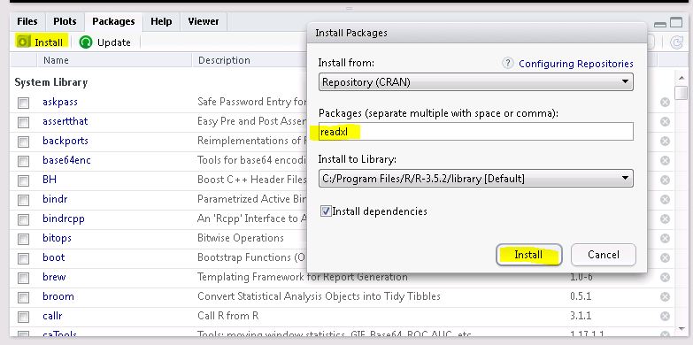

Rstudio에서 패키지 설치

2. R의 **console**화면에서 명령어 `install.packages` 함수를 이용하여 설치한다.

```r
install.packages("readxl")
```

### 패키지의 지정

패키지 `readxl`을 설치한 후 그 기능을 이용하고 싶다면 다음과 같이 `library` 함수를 사용하여 패키지를 지정해 주어야 한다.

```r
library(readxl)
```

참고로 패키지의 설치는 최초 한 번만 해주면된다. 하지만 `library` 함수를 이용한 패키지의 지정은 사용할 때마다 실행해 주어야 한다.

## 엑셀 화일의 입력

### **working directory** 지정

이제 `test.xlsx` 엑셀 화일을 원하는 디렉토리에 저장한다.

화일을 저장한 디렉토리를 **working directory**로 지정해 주어야 한다. Rstudio 메뉴에서 **session**을 선택하면 **set working directory** 메뉴가 있다. **choose directory**를 선택하고 `test.xlsx` 엑셀 화일을 저장한 디렉토리를 지정해 준다.

### 엑셀 화일의 입력

- `test.xlsx` 엑셀 화일의 자료를 데이터프레임 `seoulpop01` 에 저장해 주려면 다음과 같은 명령어를 실행한다.

```r
seoulpop01 <- read_excel("test.xlsx", col_names = TRUE)
seoulpop01
```

```
## # A tibble: 130 x 5
##    year  name       house      pop   old65
##    <chr> <chr>      <dbl>    <dbl>   <dbl>
##  1 2014  합계     4194176 10369593 1221616
##  2 2014  종로구     73101   165344   24537
##  3 2014  중구       59960   136227   19960
##  4 2014  용산구    108429   249914   34896
##  5 2014  성동구    125814   303891   36684
##  6 2014  광진구    158524   377375   38974
##  7 2014  동대문구  159880   376319   50915
##  8 2014  중랑구    176714   423411   51995
##  9 2014  성북구    193359   475961   62066
## 10 2014  강북구    141246   338410   50841
## # … with 120 more rows
```

위에서 엑셀 화일을 읽을 때 다음과 같은 점을 유의하자.

- 위에서 사용한 함수 `read_excel`은 패키지 `readxl`을 설치해야 사용할 수 있는 함수이다.
- 함수 `read_excel`는 컴마로 분리된 두 가지 인자(arguments)를 받는다. 첫 번째 인자는 문자열로 된 엑셀 화일의 이름이다(`"test.xlsx"`).
- 두 번째 인자 `col_names = TRUE` 는 선택 명령어(options)이며 엑셀 화일 `"test.xlsx"`에서 첫 행이 자료가 아니고 변수의 이름이라는 것을 알려주는 문장이다. 만약 엑셀 화일의 첫 행부터 자료가 시작된다면 `col_names = FALSE` 라고 지정해야 한다.
- `seoulpop01`은 데이터프레임 형식이 아닌 **tibble** 형식이며 이는 데이터프레임의 보다 진화된 형식이라고 볼 수 있다.

**tibble** 형식의 `seoulpop01`을 데이터프레임 형식인 `seoulpop02`으로 함수 `data.frame` 함수를 이용하여 저장하자.

```r
seoulpop02 <- data.frame(seoulpop01)
head(seoulpop02, n=30)
```

```
##    year     name   house      pop   old65
## 1  2014     합계 4194176 10369593 1221616
## 2  2014   종로구   73101   165344   24537
## 3  2014     중구   59960   136227   19960
## 4  2014   용산구  108429   249914   34896
## 5  2014   성동구  125814   303891   36684
## 6  2014   광진구  158524   377375   38974
## 7  2014 동대문구  159880   376319   50915
## 8  2014   중랑구  176714   423411   51995
## 9  2014   성북구  193359   475961   62066
## 10 2014   강북구  141246   338410   50841
## 11 2014   도봉구  136977   355712   46471
## 12 2014   노원구  221107   586056   66480
## 13 2014   은평구  202187   503243   67002
## 14 2014 서대문구  134780   320861   45309
```

[output cut: 16 more lines]

## CSV 화일의 입력

많은 경우 자료가 CSV(comma-separated values)화일로 저장된다. CSV 화일은 자료의 값(필드)를 쉼표(,) 또는 여백(space)로 구분한 텍스트 데이터 및 텍스트 파일이다. 확장자는 .csv 이며 이 화일은 MS Excel 프로그램으로 볼 수 있다.

예제 화일인 **seoulpopall.csv**의 실제 내용을 보면 다음과 같다.

```
year,name,house,pop,popm,popf,for,density,area,numhouse,old65
1991,합계,3330317,10904527,5485353,5419174,,18014,605.33,3.27,
1991,종로구,78169,236806,119127,117679,,9865,24.01,3.03,
1991,중구,61495,184142,93312,90830,,18438,9.99,2.99,
```

CSV 화일은 R 에서 함수 `read.table`를 이용하여 자료를 불러 올 수 있다. 아래는 **seoulpopall.csv** 화일의 자료를 불러오는 R 명령어이다.

```r
df <- read.table("seoulpopall.csv", sep=",", header = TRUE)
```

함수 `read.table`의 세가지 인자를 설명하면 다음과 같다.

- `"seoulpopall.csv"`: 문자열로 된 csv 화일 이름
- `sep=","` : 각 변수의 필드가 쉼표(,)로 분리된 것을 지정한다. 만약 여백(space)으로 구분되어 있다면 `sep=""`로 지정한다.
- `header = TRUE` : 첫 행이 자료가 아니고 변수의 이름이라는 것을 알려주는 문장이다.

아래는 **seoulpopall.csv** 화일의 자료가 저장된 데이터프레임 `df`의 내용이다. 자료 중에 `NA`로 표시된 부분은 자료가 없는 것, 즉 결측값(missing value, Not Available)을 의미 한다.

```r
head(df)
```

```
##   year     name   house      pop    popm    popf for. density   area
## 1 1991     합계 3330317 10904527 5485353 5419174   NA   18014 605.33
## 2 1991   종로구   78169   236806  119127  117679   NA    9865  24.01
## 3 1991     중구   61495   184142   93312   90830   NA   18438   9.99
## 4 1991   용산구   96696   294341  147914  146427   NA   13460  21.87
## 5 1991   성동구  244272   789014  401375  387639   NA   23273  33.90
## 6 1991 동대문구  149914   479776  242828  236948   NA   32477  14.77
##   numhouse old65
## 1     3.27    NA
## 2     3.03    NA
## 3     2.99    NA
## 4     3.04    NA
## 5     3.23    NA
## 6     3.20    NA
```

# 자료의 선택

## 비교연산자를 이용한 자료의 선택

이제 위에서 만든 데이터프레임 `seoulpop02`를 보면 구의 이름 `name` 이 **합계**인 자료가 나타나고 있다. `name` 이 **합계**인 자료(행)를 데이터프레임에서 제거해 보자.

첫 번째 방법은 먼저 `name` 이 **합계**인 자료(행)를 찾는 것이다. 다음과 같은 비교연산자 `==`를 사용하면 벡터 `seoulpop02$name` 이 **합계**인 행이 `TRUE`, 아닌 행이 `FALSE`로 나타나는 논리값 벡터를 만들 수 있다.

```r
myselect <- seoulpop02$name == "합계"
myselect
```

```
##   [1]  TRUE FALSE FALSE FALSE FALSE FALSE FALSE FALSE FALSE FALSE FALSE
##  [12] FALSE FALSE FALSE FALSE FALSE FALSE FALSE FALSE FALSE FALSE FALSE
##  [23] FALSE FALSE FALSE FALSE  TRUE FALSE FALSE FALSE FALSE FALSE FALSE
##  [34] FALSE FALSE FALSE FALSE FALSE FALSE FALSE FALSE FALSE FALSE FALSE
##  [45] FALSE FALSE FALSE FALSE FALSE FALSE FALSE FALSE  TRUE FALSE FALSE
##  [56] FALSE FALSE FALSE FALSE FALSE FALSE FALSE FALSE FALSE FALSE FALSE
##  [67] FALSE FALSE FALSE FALSE FALSE FALSE FALSE FALSE FALSE FALSE FALSE
##  [78] FALSE  TRUE FALSE FALSE FALSE FALSE FALSE FALSE FALSE FALSE FALSE
##  [89] FALSE FALSE FALSE FALSE FALSE FALSE FALSE FALSE FALSE FALSE FALSE
## [100] FALSE FALSE FALSE FALSE FALSE  TRUE FALSE FALSE FALSE FALSE FALSE
## [111] FALSE FALSE FALSE FALSE FALSE FALSE FALSE FALSE FALSE FALSE FALSE
## [122] FALSE FALSE FALSE FALSE FALSE FALSE FALSE FALSE FALSE
```

R 에서 `TRUE`와 `FALSE`는 논리의 참과 거짓을 나타내는 지정된 값이다.

이제 데이터프레임 행의 위치에 논리형식의 벡터 `myselect`를 넣으면 `name` 이 **합계**인 자료(행)만 선택된다.

```r
seoulpop02[ myselect, ]
```

```
##     year name   house      pop   old65
## 1   2014 합계 4194176 10369593 1221616
## 27  2015 합계 4189948 10297138 1267563
## 53  2016 합계 4189839 10204057 1300877
## 79  2017 합계 4220082 10124579 1365126
## 105 2018 합계 4263868 10049607 1416131
```

이제 비교연산자 `!=`를 이용하면 다른 값만 참이 되는 결과를 얻으므로 `name` 이 **합계**인 자료(행)을 제거할 수 있다.

```r
mydelete <- seoulpop02$name != "합계"
mydelete
```

```
##   [1] FALSE  TRUE  TRUE  TRUE  TRUE  TRUE  TRUE  TRUE  TRUE  TRUE  TRUE
##  [12]  TRUE  TRUE  TRUE  TRUE  TRUE  TRUE  TRUE  TRUE  TRUE  TRUE  TRUE
##  [23]  TRUE  TRUE  TRUE  TRUE FALSE  TRUE  TRUE  TRUE  TRUE  TRUE  TRUE
##  [34]  TRUE  TRUE  TRUE  TRUE  TRUE  TRUE  TRUE  TRUE  TRUE  TRUE  TRUE
##  [45]  TRUE  TRUE  TRUE  TRUE  TRUE  TRUE  TRUE  TRUE FALSE  TRUE  TRUE
##  [56]  TRUE  TRUE  TRUE  TRUE  TRUE  TRUE  TRUE  TRUE  TRUE  TRUE  TRUE
##  [67]  TRUE  TRUE  TRUE  TRUE  TRUE  TRUE  TRUE  TRUE  TRUE  TRUE  TRUE
##  [78]  TRUE FALSE  TRUE  TRUE  TRUE  TRUE  TRUE  TRUE  TRUE  TRUE  TRUE
##  [89]  TRUE  TRUE  TRUE  TRUE  TRUE  TRUE  TRUE  TRUE  TRUE  TRUE  TRUE
## [100]  TRUE  TRUE  TRUE  TRUE  TRUE FALSE  TRUE  TRUE  TRUE  TRUE  TRUE
## [111]  TRUE  TRUE  TRUE  TRUE  TRUE  TRUE  TRUE  TRUE  TRUE  TRUE  TRUE
## [122]  TRUE  TRUE  TRUE  TRUE  TRUE  TRUE  TRUE  TRUE  TRUE
```

```r
head(seoulpop02[ mydelete, ], n=15)
```

```
##    year     name  house    pop old65
## 2  2014   종로구  73101 165344 24537
## 3  2014     중구  59960 136227 19960
## 4  2014   용산구 108429 249914 34896
## 5  2014   성동구 125814 303891 36684
## 6  2014   광진구 158524 377375 38974
## 7  2014 동대문구 159880 376319 50915
## 8  2014   중랑구 176714 423411 51995
## 9  2014   성북구 193359 475961 62066
## 10 2014   강북구 141246 338410 50841
## 11 2014   도봉구 136977 355712 46471
## 12 2014   노원구 221107 586056 66480
## 13 2014   은평구 202187 503243 67002
## 14 2014 서대문구 134780 320861 45309
## 15 2014   마포구 169492 395830 47360
## 16 2014   양천구 179069 490708 48175
```

비교연산자는 다음과 같은 6가지가 있다.

- `==` : is equal?
- `!=` : is not equal?
- `>` or `>=`: is greater (greater or equal)?
- `<` or `<=` : is less (less or equal)?
- `&` : AND 연산
- `|` : OR 연산

만약에 자료에서 2018년도 구인구가 50만명을 넘는 자료만 선택하여고 한다면 다음과 같은 명령어로 선택이 가능하다. 여기서 연도를 나타내는 `seoulpop02$year`의 자료값이 문자열인것을 유의하자. 인구를 나타내는 변수 `seoulpop02$pop`는 숫자이다.

```r
myselect2 <- seoulpop02$year == "2018" & seoulpop02$pop > 500000
seoulpop02[myselect2,]
```

```
##     year   name   house      pop   old65
## 105 2018   합계 4263868 10049607 1416131
## 116 2018 노원구  217655   548160   77096
## 121 2018 강서구  258503   603611   79660
## 126 2018 관악구  262222   520040   72249
## 128 2018 강남구  228775   547453   67085
## 129 2018 송파구  270866   673507   81364
```

## 패키지 `dplyr`을 이용한 자료의 선택

위에서 비교연산자를 이용하면 데이터프레임에서 조건에 맞는 자료만을 선택할 수 있는 방법을 알아보았다. 이러한 자료의 선택은 패키지 `dplyr`를 사용하면 더욱 쉽게 작업을 할 수 있다.

먼저 위에서 한 것과 같은 동일한 방법으로 패키지 `dplyr`을 설치하고(전에 설치했다면 다시 설치할 필요없다) 이용할 수 있도록 지정한다.

```r
library(dplyr)
```

패키지 `dplyr` 의 함수 `filter`를 이용하면 위에서와 같은 작업을 다음과 같이 수행할 수 있다. 이제 데이터프레임 `seoulpop`는 구의 이름이 **합계**인 자료가 제외된 자료이다.

```r
seoulpop <- filter(seoulpop02, name != "합계")
head(seoulpop, n=30)
```

```
##    year     name  house    pop old65
## 1  2014   종로구  73101 165344 24537
## 2  2014     중구  59960 136227 19960
## 3  2014   용산구 108429 249914 34896
## 4  2014   성동구 125814 303891 36684
## 5  2014   광진구 158524 377375 38974
## 6  2014 동대문구 159880 376319 50915
## 7  2014   중랑구 176714 423411 51995
## 8  2014   성북구 193359 475961 62066
## 9  2014   강북구 141246 338410 50841
## 10 2014   도봉구 136977 355712 46471
## 11 2014   노원구 221107 586056 66480
## 12 2014   은평구 202187 503243 67002
## 13 2014 서대문구 134780 320861 45309
## 14 2014   마포구 169492 395830 47360
```

[output cut: 16 more lines]

함수 `filter`의 첫 번째 인자는 데이터프레임의 이름이다. 그 다음 인자들는 차례로 원하는 조건을 열거하여 컴마로 분리하면 조건들에 맞는 자료만 선택하게 된다. 조건문을 쓸 때 데이터프레임안의 변수명만 사용하면 된다.

위에서 2018년도 구인구가 50만명을 넘는 자료만 선택하는 작업을 함수 `filter`를 이용하여 수행하고 `tempdata`에 저장해 보자.

```r
tempdata <- filter(seoulpop,  year == "2018" , pop > 500000)
tempdata
```

```
##   year   name  house    pop old65
## 1 2018 노원구 217655 548160 77096
## 2 2018 강서구 258503 603611 79660
## 3 2018 관악구 262222 520040 72249
## 4 2018 강남구 228775 547453 67085
## 5 2018 송파구 270866 673507 81364
```

# 새로운 변수의 생성

이제 자료의 기존 변수들을 이용하여 새로운 변수를 사용하는 방법을 알아보자.

먼저 데이터프레임 `seoulpop` 의 자료를 이용하여 구별 65세 이상 노인인구의 비율을 가지는 새로운 변수 `myratio`를 구해보자

```r
myratio <- seoulpop$old65 / seoulpop$pop
myratio
```

```
##   [1] 0.14839970 0.14652015 0.13963203 0.12071434 0.10327658 0.13529745
##   [7] 0.12280031 0.13040144 0.15023492 0.13064220 0.11343626 0.13314045
##  [13] 0.14121068 0.11964732 0.09817447 0.10865659 0.11197447 0.11453319
##  [19] 0.11823622 0.12480770 0.11763478 0.10449098 0.09845641 0.09679306
##  [25] 0.10440403 0.15194540 0.15113639 0.14406496 0.12510121 0.10759635
##  [31] 0.14041367 0.12922221 0.13476659 0.15727844 0.13755481 0.11917416
##  [37] 0.13879040 0.14471457 0.12199794 0.10306129 0.11406921 0.11816658
##  [43] 0.12128807 0.12321600 0.12987737 0.12283779 0.10920582 0.10370256
##  [49] 0.10231318 0.11209291 0.15495733 0.15330819 0.14653083 0.12782222
##  [55] 0.11136940 0.14436475 0.13451310 0.13867557 0.16344828 0.14420222
##  [61] 0.12409928 0.14408483 0.14623271 0.12357280 0.10804927 0.11802280
##  [67] 0.12389902 0.12675630 0.12745004 0.13365130 0.12738034 0.11292713
##  [73] 0.10824449 0.10687184 0.11861414 0.15939656 0.15887899 0.15088118
##  [79] 0.13198448 0.11805865 0.15223040 0.14356800 0.14547646 0.17234651
##  [85] 0.15448512 0.13303409 0.15178888 0.15157463 0.12860857 0.11627770
##  [91] 0.12500021 0.13315095 0.13479769 0.13427308 0.14016152 0.13446362
##  [97] 0.11945415 0.11596073 0.11410173 0.12753458 0.16403518 0.16223928
## [103] 0.15357624 0.13514060 0.12294139 0.15690101 0.15148954 0.15140489
## [109] 0.18022080 0.16380554 0.14064507 0.15875620 0.15617185 0.13156934
## [115] 0.12398936 0.13197241 0.14094179 0.14069309 0.13794103 0.14528866
## [121] 0.13892970 0.12495578 0.12254020 0.12080647 0.13606686
```

새로운 변수 `myratio`를 데이터프레임 `seoulpop` 에 **old65ratio**이라는 변수이름으로 포함시키려면 다음과 같은 명령어를 사용하면 된다.

```r
seoulpop$old65ratio <- myratio
head(seoulpop)
```

```
##   year     name  house    pop old65 old65ratio
## 1 2014   종로구  73101 165344 24537  0.1483997
## 2 2014     중구  59960 136227 19960  0.1465201
## 3 2014   용산구 108429 249914 34896  0.1396320
## 4 2014   성동구 125814 303891 36684  0.1207143
## 5 2014   광진구 158524 377375 38974  0.1032766
## 6 2014 동대문구 159880 376319 50915  0.1352974
```

위와 같은 새로운 변수의 생성은 패키지 `dplyr` 의 함수 `mutate`를 사용하면 편하다. 구별 65세 이상 노인인구의 비율을 백분율(percentage)로 저장하는 새로운 변수 **old65per**를 데이터프레임 `seoulpop`에 생성해 보자.

```r
seoulpop <- mutate(seoulpop, old65per = (old65/pop)*100 )
head(seoulpop)
```

```
##   year     name  house    pop old65 old65ratio old65per
## 1 2014   종로구  73101 165344 24537  0.1483997 14.83997
## 2 2014     중구  59960 136227 19960  0.1465201 14.65201
## 3 2014   용산구 108429 249914 34896  0.1396320 13.96320
## 4 2014   성동구 125814 303891 36684  0.1207143 12.07143
## 5 2014   광진구 158524 377375 38974  0.1032766 10.32766
## 6 2014 동대문구 159880 376319 50915  0.1352974 13.52974
```

# 자료의 그룹별 요약

이제 자료를 그룹별로 요약하여 기초 통계량을 구하는 방법을 알아보자.

이전의 예제에서 구의 이름 `name`이 **합계**인 자료를 모두 제거했는데 데이터프레임 `seoulpop` 를 이용하여 이제 연도별 서울 전체인구를 구하는 방법을 알아보자. 먼저 데이터프레임에 있는 연도 `year`를 그룹으로 구별인구 `pop`를 합계해서 년도별 서울인구를 구해야 한다.

이러한 작업은 패키지 `tidyr`의 연결연산자 `%>%`를 사용하면 편하다. 먼저 패키지 `tidyr`를 지정하자 (앞에서와 마찬가지로 패키지 `tidyr`가 설치되어 있지 않으면 먼저 설치한다)

```r
library(tidyr)
```

이제 연결연산자를 이용하여 연도별 서울 전체인구를 구하는 명령어는 다음과 같다.

```r
seoulpop %>% group_by(year) %>% summarise(totalpop = sum(pop))
```

```
## # A tibble: 5 x 2
##   year  totalpop
##   <chr>    <dbl>
## 1 2014  10369593
## 2 2015  10297138
## 3 2016  10204057
## 4 2017  10124579
## 5 2018  10049607
```

연산자 `%>%` 는 연결 연산자(pipe operator)라고 하며 함수를 축차적으로 연속하여 사용하지 않고 왼쪽에서 생성된 자료와 정보를 오른쪽 함수의 인자로 전달 해주는 역활을 하는 유용한 연산자이다. 위의 명령어는 3개의 단계로 이루어 진다.

- 데이터프레임 `seoulpop` 지정한다 (지정한 후에는 변수이름을 자유롭게 이용할 수 있다)
- 변수 `year`를 함수 `group_by`로서 그룹변수로 지정한다
- 새로운 변수 `totalpop`는 인구 `pop`를 함수 `sum`을 이용하여 합계를 구한다 (함수의 작업은 앞에서 지정된 그룹별로 이루어 진다).

위의 요약된 정보를 `yeartotal`에 저장하려면 다음과 같은 명령어를 사용하면 된다.

```r
yeartotal <- seoulpop %>% group_by(year) %>% summarise(totalpop = sum(pop))
yeartotal
```

```
## # A tibble: 5 x 2
##   year  totalpop
##   <chr>    <dbl>
## 1 2014  10369593
## 2 2015  10297138
## 3 2016  10204057
## 4 2017  10124579
## 5 2018  10049607
```

또한 예제로서 2014년부터 2018년까지 5년간 구별 평균인구를 구해보자.

```r
seoulpop %>% group_by(name) %>% summarise(meanpop = mean(pop))
```

```
## # A tibble: 25 x 2
##    name   meanpop
##    <chr>    <dbl>
##  1 강남구 569170.
##  2 강동구 453081.
##  3 강북구 330891.
##  4 강서구 600263.
##  5 관악구 525513.
##  6 광진구 373604
##  7 구로구 448276
##  8 금천구 255273.
##  9 노원구 568345.
## 10 도봉구 349422.
## # … with 15 more rows
```

다른 예제로서 2014년부터 2018년까지 5년간 구별 평균인구, 최소인구, 최대인구를 동시에 구해보자.

```r
seoulpop %>% group_by(name) %>% summarise(minpop=min(pop), meanpop = mean(pop), maxpop=max(pop) )
```

```
## # A tibble: 25 x 4
##    name   minpop meanpop maxpop
##    <chr>   <dbl>   <dbl>  <dbl>
##  1 강남구 547453 569170. 583446
##  2 강동구 431920 453081. 481332
##  3 강북구 322915 330891. 338410
##  4 강서구 591653 600263. 608255
##  5 관악구 520040 525513. 531960
##  6 광진구 371063 373604  377375
##  7 구로구 438486 448276  457131
##  8 금천구 253491 255273. 258030
##  9 노원구 548160 568345. 586056
## 10 도봉구 341649 349422. 355712
## # … with 15 more rows
```